# Social Media Analytics, 3rd lecture

Analysis code examples

VU Amsterdam

# This document

For the final assignment you are allows to use any skills that you have learned to perform the analyses. This includes using Excel and SPSS.

- For the manual content analysis the results of the coding is an Excel/Sheets file (based on the template).
- For the automatic content analysis, the code from Practical 6 shows you how to export the results from your machine learning analysis to a CSV file. You can open this CSV file in Excel/Google sheets or SPSS.

If you do the analysis in Excel or SPSS, we expect you to apply skills that you learned in previous methods courses. But off course, you can also perform the analyses in R. Since none (or at least most) of you haven’t learned how to perform statistical analysis and visualization in R in previous courses, the current document provides some code and examples.

# Reading your data into R

If you followed the steps from practical 6, you should have a csv file with your (Reddit) data with the predicted sentiment (or other predicted label) scores.

```r
library(tidyverse)

d = read_csv('~/projects/r_for_sma/tutorials/data/rstats_reddit_with_sentiment.csv')
```

If you followed all the steps, this data should have among other things a date, jupvotes, sentiment and sentiment_score. This will be the main data we’ll be looking at for the example analyses.

```r
select(d, date, upvotes, sentiment, sentiment_score)
```

```
## # A tibble: 2,693 × 4
##    date                upvotes sentiment sentiment_score
##    <dttm>                <dbl> <chr>               <dbl>
##  1 2023-06-05 14:00:49    2387 negative               -1
##  2 2023-06-05 14:24:11     121 neutral                 0
##  3 2023-06-05 14:36:37      32 negative               -1
##  4 2023-06-05 14:39:53     434 positive                1
##  5 2023-06-05 14:47:43      28 neutral                 0
##  6 2023-06-05 15:01:08     204 negative               -1
##  7 2023-06-05 15:02:19     126 neutral                 0
##  8 2023-06-05 15:10:55      70 negative               -1
##  9 2023-06-05 15:18:21      77 negative               -1
## 10 2023-06-05 15:34:54      -6 negative               -1
## # ℹ 2,683 more rows
```

# Summarizing data

First, let’s look at how to summarize the sentiment score. Here we use the summarize function to calculate summarizing statistics, like the mean and standard deviation. Notice that we add the `na.rm=T` argument, which means that we ignore any missing values (NA) if they happen to occur.

```r
d %>%
  summarize(mean_sentiment = mean(sentiment_score, na.rm=T),
            sd_sentiment = sd(sentiment_score, na.rm=T),
            n=n())
```

```
## # A tibble: 1 × 3
##   mean_sentiment sd_sentiment     n
##            <dbl>        <dbl> <int>
## 1         -0.364        0.742  2693
```

In this case we summarize everything, but we often want to summarize per group. For example, if we want to compare sentiment before and after a certain point in time, we can first divide our data into periods, and then summarize per period.

## Breaking the data into periods

There are two ways to divide the data into periods. One is to manually specify the period based on the date. The easiest way is to first create a `period` column (with d$period) and give it the value for the earliest period. Then we change the value for the rows in the data where the date is greater than or equal to (>=) a specific day.

```r
d$period = '2022'
d$period[d$date >= '2023-01-01'] = '2023 january/march'
d$period[d$date >= '2023-04-01'] = '2023 april/now'
```

Now we can again summarize the data, but this time we group by the period. The summary will then automatically be computed for each group.

```r
d %>%
  group_by(period) %>%
  summarize(mean_sentiment = mean(sentiment_score, na.rm=T))
```

```
## # A tibble: 3 × 2
##   period             mean_sentiment
##   <chr>                       <dbl>
## 1 2022                       -0.255
## 2 2023 april/now             -0.424
## 3 2023 january/march         -0.407
```

The second way to break the data into periods is by using broader time units like months. The following code adds several common time units.

```r
d = d %>%
  mutate(month = as.Date(cut(date, breaks='month')),
         week = as.Date(cut(date, breaks='week')))
```

Now we can use the month and week to group the data.

```r
d %>%
  group_by(month) %>%
  summarize(mean_sentiment = mean(sentiment_score, na.rm=T))
```

```
## # A tibble: 18 × 2
##    month      mean_sentiment
##    <date>              <dbl>
##  1 2022-01-01        -0.333
##  2 2022-02-01         0.75
##  3 2022-03-01        -0.182
##  4 2022-04-01        -0.459
##  5 2022-05-01         0.421
##  6 2022-06-01        -0.292
##  7 2022-07-01        -0.516
##  8 2022-08-01        -0.1
##  9 2022-09-01         0.5
## 10 2022-10-01        -0.0182
## 11 2022-11-01        -0.667
## 12 2022-12-01        -0.260
## 13 2023-01-01        -0.415
## 14 2023-02-01        -0.377
## 15 2023-03-01        -0.365
## 16 2023-04-01        -0.316
## 17 2023-05-01        -0.0645
## 18 2023-06-01        -0.509
```

```r
d %>%
  group_by(week) %>%
  summarize(mean_sentiment = mean(sentiment_score, na.rm=T))
```

```
## # A tibble: 48 × 2
##    week       mean_sentiment
##    <date>              <dbl>
##  1 2022-01-03         -0.333
##  2 2022-01-31          1
##  3 2022-02-21          0.714
##  4 2022-03-07         -0.333
##  5 2022-03-14          0.5
##  6 2022-04-04         -0.378
##  7 2022-04-25         -0.55
##  8 2022-05-16          0.556
##  9 2022-05-23          1
## 10 2022-05-30          0.1
## # ℹ 38 more rows
```

### Visualizing

Now that we have proper data, we can get to plotting. We’re using the [ggplot2](https://ggplot2.tidyverse.org/) package for this (which is included in the tidyverse). This is a very powerful visualization tool, but it also takes some time getting used to. Here we will just give you the code. In the video we provide some details on how the code works, but the main focus is on how you can use this to visualize your own data. For those interested, we also have a [short tutorial](https://github.com/ccs-amsterdam/r-course-material/blob/master/tutorials/r-tidy-3_7-visualization.md) on using ggplot2.

To visualize the data, we’ll take two steps. First, we summarize the data as we did above, and second we plot it. This time, we’ll assign the summarized data to a name. Here we just use `agg` (short for aggregation), but you can pick any name you want.

```r
agg = d %>%
  group_by(week) %>%
  summarize(sentiment = mean(sentiment_score, na.rm=T))
```

Now we have the mean sentiment score per week, and we can plot it in a line chart

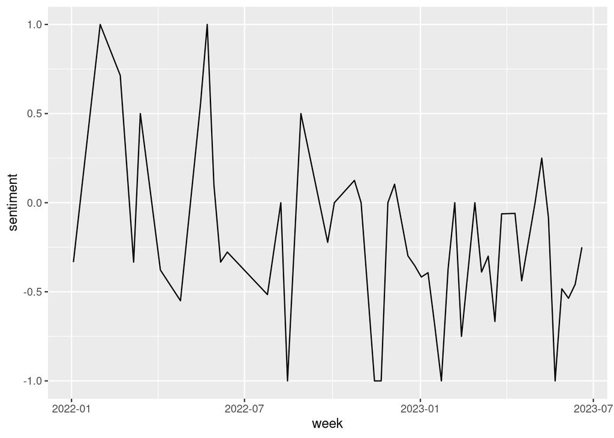

```r
ggplot(agg) +
  geom_line(aes(x=week, y=sentiment))
```

Likewise, you could instead use the month. Here we combine the summarize and visualization step in one command

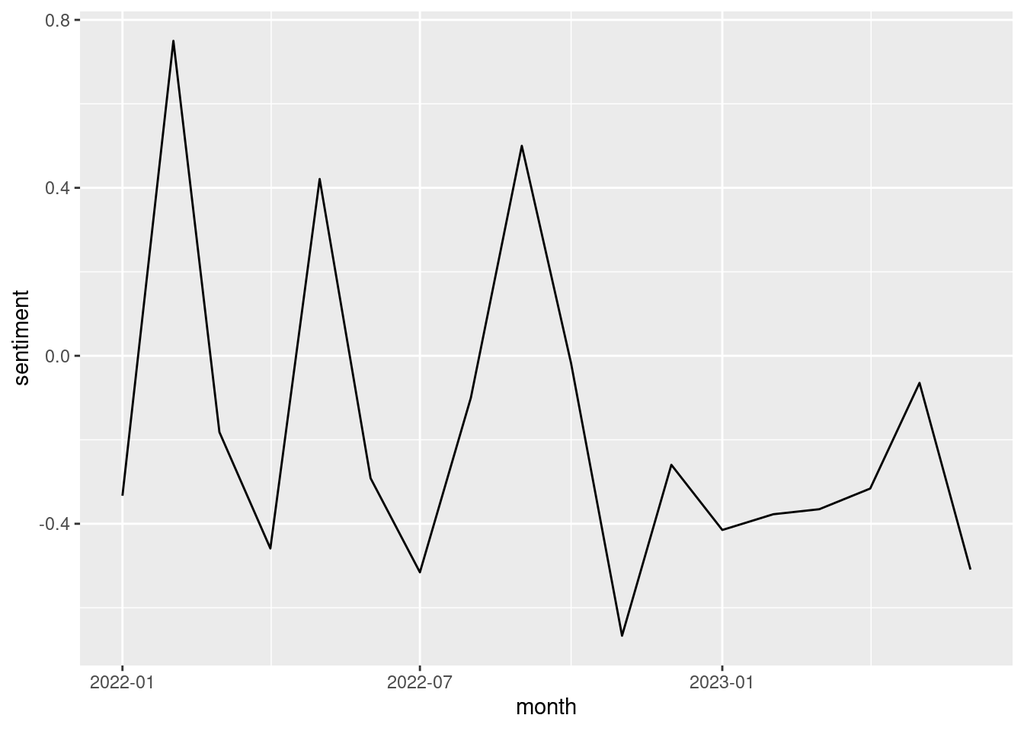

```r
d %>%
  group_by(month) %>%
  summarize(sentiment = mean(sentiment_score, na.rm=T)) %>%
  ggplot() +
  geom_line(aes(x=month, y=sentiment))
```

# Basic statistics

In the assignment you need to report some basic descriptive statistics. If you for instance state that “the sentiment of tweets has become more negative after event x happened”, you’ll need to put some numbers to this claim.

Here we discuss how to get some basic descriptive statistics and do some statistical tests given this type of data frame in R. We assume you already executed the code discussed above, and so already have the period, week and month variables.

## one-sample t-test

Perhaps the simplest test is to just see if an average is significantly different from zero.

```r
t.test(d$sentiment_score)
```

```
##
##  One Sample t-test
##
## data:  d$sentiment_score
## t = -25.481, df = 2692, p-value < 2.2e-16
## alternative hypothesis: true mean is not equal to 0
## 95 percent confidence interval:
##  -0.3923101 -0.3362454
## sample estimates:
##  mean of x
## -0.3642778
```

The output tells us the mean of x (where x is the sentiment score), as well as the t-value, degrees of freedom (df), p-value and confidence interval.

## independent samples t-test

If you are comparing periods, the independent samples t-test can be used. In an independent samples t-test we compare between two groups, so we need to provide a variable with 2 values. One easy way to do this is to directly provide a `condition`. Here we use `d$date >= ‘2023-01-01’ to create a variable that is TRUE if the date is 2023 or later, and FALSE if it’s before 2023.

```r
t.test(sentiment_score ~ d$date >= '2023-01-01', data=d)
```

```
##
##  Welch Two Sample t-test
##
## data:  sentiment_score by d$date >= "2023-01-01"
## t = 5.0454, df = 1545.3, p-value = 5.06e-07
## alternative hypothesis: true difference in means between group FALSE and group TRUE is not equal to 0
## 95 percent confidence interval:
##  0.0955928 0.2171939
## sample estimates:
## mean in group FALSE  mean in group TRUE
##          -0.2552147          -0.4116081
```

## ANOVA

If you’re comparing multiple groups, you could use an ANOVA.

```r
period_anova = aov(sentiment_score ~ period, data=d)
summary(period_anova)
```

```
##               Df Sum Sq Mean Sq F value  Pr(>F)
## period         2     14   7.009   12.85 2.8e-06 ***
## Residuals   2690   1468   0.546
## ---
## Signif. codes:  0 '***' 0.001 '**' 0.01 '*' 0.05 '.' 0.1 ' ' 1
```

This only tells you whether there are differences between the groups. You can do a post-hoc test to compare specific groups.

```r
TukeyHSD(period_anova)
```

```
##   Tukey multiple comparisons of means
##     95% family-wise confidence level
##
## Fit: aov(formula = sentiment_score ~ period, data = d)
##
## $period
##                                          diff         lwr        upr     p adj
## 2023 april/now-2022               -0.16920388 -0.26664896 -0.0717588 0.0001419
## 2023 january/march-2022           -0.15154005 -0.22824730 -0.0748328 0.0000113
## 2023 january/march-2023 april/now  0.01766383 -0.07187449  0.1072022 0.8887560
```

## Regression

The most versatile to analyze your data is regression analysis, also referred to as linear models. (t-tests and anovas are really just linear models in disguise).

To work with linear models in R we’ll also install the `sjPlot` package. This makes it easy to make APA style regression tables.

```r
library(sjPlot)
```

R regression analysis works with a formula of the format `y ~ x1 + x1 + ...`. So if our dependent variable (y) is upvotes for a reddit comment, and we want to see if we can explain/predict this based on the sentiment, we could specify this as follows

```r
m = lm(upvotes ~ sentiment_score, data=d)
tab_model(m)
```

|  | upvotes |  |  |
| --- | --- | --- | --- |
| Predictors | Estimates | CI | p |
| (Intercept) | 21.85 | 16.60 – 27.10 | **<0.001** |
| sentiment score | -3.64 | -10.00 – 2.72 | 0.262 |
| Observations | 2693 |  |  |
| R<sup>2</sup> / R<sup>2</sup> adjusted | 0.000 / 0.000 |  |  |

# Disclaimer on statistical modeling in this course

It should be pointed out that for these types of analysis, one would often use more advanced types of statistical analysis, or at least different types of analysis that you have not (yet) covered in your studies. This is because our dependent variable is often not interval/ratio and normal (sentiment score has only 3 possible values: -1, 0 and 1) and with longitudinal data over time we would actually need to take into account that our observations are often not independent.

Still, you can use things like t-tests, anova and regression in a useful way, and we encourage you to try to apply what you know. But if you at some points feel that there should be better approaches, you are correct.